# Group project 4

Yixin Xie, Aonan Chen, Wufan Tang, Ziyang Wang

3/2/2021

# Introduction

The COVID 19 pandemic has created large influences on the economy, education, and healthcare worldwide. With the continuous consequences of the COVID, people are curious about the key factors which affect the postive rate per capita. Under such circumstances, we are motivated to find factors that connect closely to the postive rate per capita of the COVID-19. And making an appropriate prediction model which is generated by the linear lasso model. We choose to use the lasso model in this report because the parameters are relatively small here. And it is good at minimizing prediction errors.

5 datasets are sorted, filtered, and merged to form the final dataset for analysis. The main dataset we are using here is the COVID-19 global data from the World Health Organization(WHO), which is a daily record of the COVID-19 cases and death cases corresponding to countries with the WHO region code. The data is significant since WHO is an official agency of the United Nations (UN), which holds the responsibility of guiding global public health. The other four datasets come from the United Nations Development Programme(UNDP), the University of Oxford, and Kaggle(raw data is from Worldometer).

The WHO dataset contains global data from 2020/01/02 to 2021/03/02, but we only use the data on 2021/03/01 to make an easier manipulation. Also, the WHO region code would be used for continental classification. The key dependent variable in this project is the postive rate per capita for COVID 19 by country. Independent variables we are choosing here are data that can strongly indicate the situation of the population, economy, and health system. The basic unit here is per individual country. And the final data is filtered carefully by the COVID stringency index.

The results of the report are meaningful because it shows the relationship between the COVID 19 infection rate and the population, economy, health system, along with a relatively accurate prediction.

# Background

Final dataset is created by the manipulation of merging 5 datasets. The categories of the dataset can be classified mainly as postive rate per capita, population, region, economy and health system. And there are 153 countries studies in this project.

For the infection, we are looking at the infected rate, it is originally the cumulative infection cases in the WHO data. We transformed the cumulative cases into the postive rate per capita in this report – infected rate = cumulative cases/popluation of the specific country. We are doing the transformation because we want to minimizing the effect of population base when we are considering the effect of independent variables. It is not fair to compare the infected cases together while the denominator is quite different. For example, if one party has 100 people, and another has 1000 people. Both of them has 50 infected cases for COVID 19. It would be very inappropriate saying that the COVID conditions are the same for the two parties.

The population is interpreted such by the total population number, land area, population density, urban population percent. The region is grouped into 6 WHO region: African Region(AFRO), Region of the Americas(AMRO), South-East Asia Region(SEARO), European Region(EURO), Eastern Mediterranean Region(EMRO), and Western Pacific Region(WPRO).

The economy is interpreted by GDP per capita.

The health system is interpreted by the health expenditure, in % of GDP.

In summary, the final dataset contains:

- postive rate per capita variable: “infected_rate”
- demography variable: “WHO_region”
- population variable: “Population 2020”, “Pop_yearly_change”, “Net.Change”, “population_density”, “land_area”, “Migrant_net_change”, “Fert_rate”, ’median_age“,”urban_population_percent"
- economy variable: “GDP_per_capita”
- health system variable: “health_expenditure_of_GDP”

# Data Analysis

After data matching and filtering, we organize the data into the final dataset The first 6 rows and the overall summary of the final data is shown below.

```r
head(d_rate_table2)
```

```
##   infected_rate WHO_region Population2020 Pop_yearly_change Net.Change
## 1   0.001438534       EMRO       38742911              2.33     886592
## 2   0.002588770       AFRO       43685618              1.85     797990
## 3   0.000637376       AFRO       32644783              3.27    1040977
## 4   0.046714866       AMRO       45111229              0.93     415097
## 5   0.001138795       WPRO       25439164              1.18     296686
## 6   0.050701521       EURO        8996022              0.57      51296
##   population_density land_area Migrant_net_change Fert_rate median_age
## 1                 60    652860             -62920        34          4
## 2                 18   2381740             -10000        20         15
## 3                 26   1246700               6413        43          3
## 4                 17   2736690               4800        12         18
## 5                  3   7682300             158246         7         24
## 6                109     82409              65000         4         28
##   urban_population_percent GDP_per_capita health_expenditure_of_GDP
## 1                       25             48                        10
## 2                       73              5                        48
## 3                       67            132                        18
## 4                       93             49                        72
## 5                       86            112                        73
## 6                       57            124                         3
##   median_stringency
## 1             21.30
## 2             72.22
## 3             71.30
## 4             82.87
## 5             67.13
## 6             53.70
```

```r
summary(d_rate_table2)
```

```
##  infected_rate      WHO_region Population2020      Pop_yearly_change
##  Min.   :0.000000   AFRO :36   Min.   :9.822e+04   Min.   :-1.350
##  1st Qu.:0.001391   AMRO :28   1st Qu.:4.110e+06   1st Qu.: 0.440
##  Median :0.010881   EMRO :16   Median :1.043e+07   Median : 1.130
##  Mean   :0.022202   EURO :46   Mean   :4.832e+07   Mean   : 1.221
##  3rd Qu.:0.040188   SEARO: 9   3rd Qu.:3.470e+07   3rd Qu.: 1.950
##  Max.   :0.115838   WPRO :18   Max.   :1.438e+09   Max.   : 3.840
##    Net.Change       population_density   land_area        Migrant_net_change
##  Min.   : -383840   Min.   :   2.0     Min.   :     320   Min.   :-532687
##  1st Qu.:    8784   1st Qu.:  26.0     1st Qu.:   48320   1st Qu.: -14704
##  Median :  106105   Median :  83.0     Median :  192530   Median :   -800
##  Mean   :  483409   Mean   : 153.7     Mean   :  788847   Mean   :   8939
##  3rd Qu.:  447563   3rd Qu.: 152.0     3rd Qu.:  579320   3rd Qu.:  11731
##  Max.   :13586631   Max.   :2239.0     Max.   :16376870   Max.   : 954806
##    Fert_rate       median_age    urban_population_percent GDP_per_capita
##  Min.   : 1.00   Min.   : 1.00   Min.   :13.00            Min.   :  1.00
##  1st Qu.: 6.00   1st Qu.: 9.00   1st Qu.:43.00            1st Qu.: 39.00
##  Median :12.00   Median :16.00   Median :59.00            Median : 76.00
##  Mean   :15.58   Mean   :16.24   Mean   :60.01            Mean   : 76.26
##  3rd Qu.:25.00   3rd Qu.:24.00   3rd Qu.:79.00            3rd Qu.:114.00
##  Max.   :46.00   Max.   :33.00   Max.   :98.00            Max.   :152.00
##  health_expenditure_of_GDP median_stringency
##  Min.   : 1.00             Min.   : 8.33
##  1st Qu.:26.00             1st Qu.:45.37
##  Median :42.00             Median :56.48
##  Mean   :41.14             Mean   :55.01
##  3rd Qu.:55.00             3rd Qu.:67.59
##  Max.   :76.00             Max.   :82.87
```

There are 14 variables in this data set:

*infected_rate: it is the Positive rate per capita for each observations during the period of 2020/01/02 to 2021/03/01, calculated by cumulative cases over Population

*WHO_region: it is the WHO region of the observation.

*Population2020: This columns contains the population of different countries in 2020

*Pop_yearly_change :This columns contains the population percentage change by yearly in 2020. For example, 2.33= 2.33%

*Net.Change:This columns contains the net change of the population in 2020

*population_density:The column contains the density of the population (P/Km²) in 2020

*land_area:This column contain the land area in terms of kilometer square in 2020

*Migrant_net_change:This column represents the migrants of the countries in 2020

*median_age:This column represents the median age (Middle Age or the average age) lifespan of the country in 2020

*urban_population_percent:This column represents the urban population

*GDP_per_capita:This represent the GDP per capita for each observation in 2020

*median_stringency: The nine metrics used to calculate the Government Stringency Index are: school closures; workplace closures; cancellation of public events; restrictions on public gatherings; closures of public transport; stay-at-home requirements; public information campaigns; restrictions on internal movements; and international travel controls. For detail calculations of the index, please see this page: https://github.com/OxCGRT/covid-policy-tracker/blob/master/documentation/index_methodology.md

# Visualization

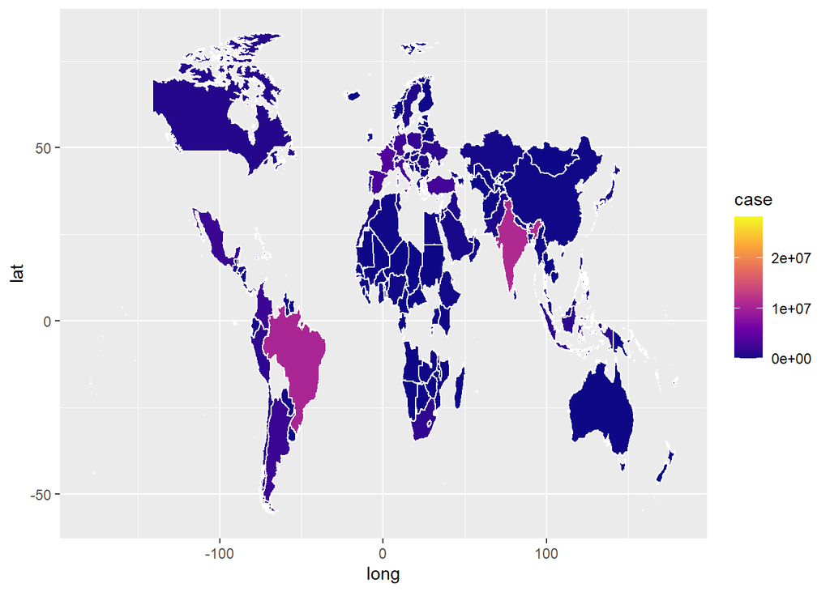

The Scatter plot below shows the relationship between the GDP and the infected rate, coloring by the groups of WHO regions. According to the plot, we can see that the relationship between the two variables seems positive. Especially for the EURO, AMRO, EMRO region, the higher the GPA per capital, the higher the infected rate.

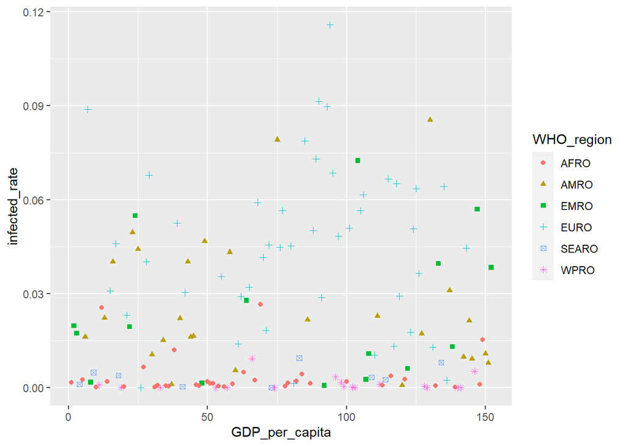

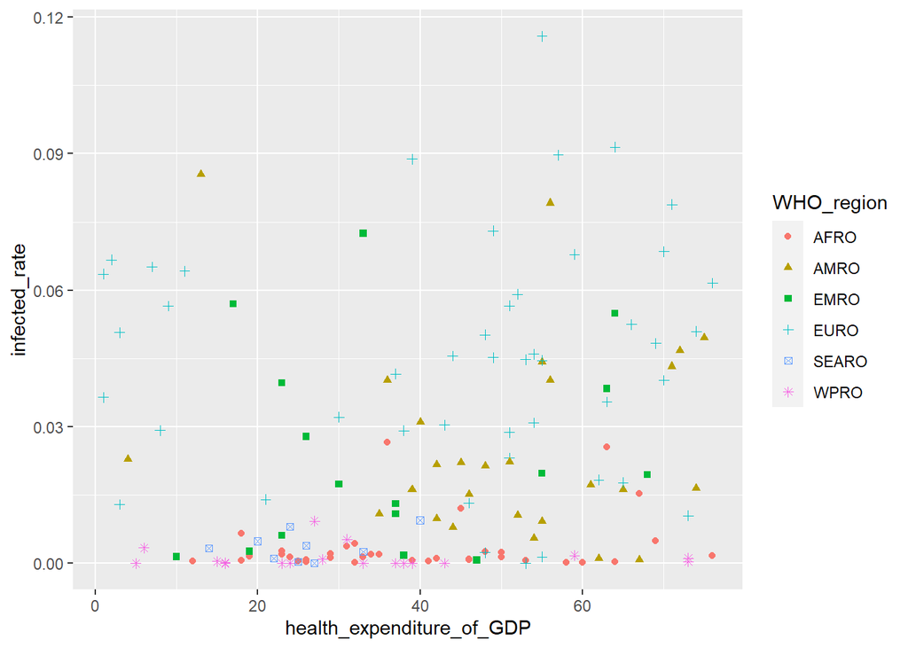

# Inferential Analysis

COVID-19 has grabbed our attention since it was reported to the WHO on December 31, 2019. The outbreak of COVID-19 rapidly rises globally pandemic panic, and infected patients are diagnosed as an acute respiratory syndrome coronavirus. The number of deaths and infections are changing day by day, we can obtain the most up-to-date information from both WHO (World Health Organization) and CDC (Centers for Disease Control and Prevention). For this inferential part, we combine a pre-obtained raw dataset from the WHO with some open regional indicators. We are interested in the true meanings behind the large number of infection counts through time and across regions. We consider explaining the rate of infections by those indicators. Ultimately, the results we will derive would have meanings for future predictions on infections and the rate.

To see the objective laws of changing infected rate across regions, we consider using Lasso regression, Ridge regression and Elastic net. The basic idea of them is the same in terms of they are all linear regressions but they have respectively different pros and cons. In our case, we need to be aware of the problem of overfitting and the effectiveness of sample validations. We need to get acquainted with the bias-variance trade-off problem in the linear regression and how we can solve it with regularization.

The basic model is: y = β<sub>0</sub> + β<sub>1</sub>X1 + β<sub>2</sub>X2 + ··· + β<sub>n</sub>Xn + ϵ

Introduction of Notation: y: Response variable. It represents the infected rate across regions. β<sub>1</sub>,···,β<sub>n</sub>: coefficients or parameters of the predictor variables β0: Intercept of the model. An uncaptured amount of variations. X1,···,Xn: predictor variables. ϵ: Residuals or error terms. Here, β<sub>1</sub>,···,β<sub>n</sub> determine the amount of expected change in the y (response variable) when there is a unit increase in the predictor variables. β0 is a constant and does not change when predictor variables change.

One of the most important idea of Ridge regression is the way it solves the model complexity. As we want to explain the response variable precisely, we often introduce many predictor variables. In this case, the increase in number of predictor variables increases the variances but it decreases the bias. For regularization, we need to find a balance between the extent of variances and bias so that we can get reliable results. The trade-off between them is significant since an increase in variance decreases the bias. They have negative relationship.

Lasso regression is similar to Ridge regression. It also introduces𝜆to penalize model complexity. However, it does not penalize sum of squared coefficients. It penalize the absolute values. In this way, Lasso regression inherits the idea of Ridge regression and conducts penalty on non-zero coefficients. The major difference between Lasso and Ridge regression is that Lasso results in zeroed coefficients where can never happen in Ridge.

In this part, we are going partition the samples into test set(20%) and training set(80%), and we use the glmnet function in R to construct lasso, ridge and net elastic models. Through standardized cross validation of 10 folds, we select the best lambda that minimize the mean square error based on the cross validation.

Based on the cross validation plot, we can observe the plot is sparse, which implies that the lasso model might have a best prediction outcome out of the 3 models.

After acquring the best lambda and the model, we use the predict the model on the test set. By this prediction, we can interpret the outcome betas in a similar way of interpreting betas for the linear regression model.

## lasso

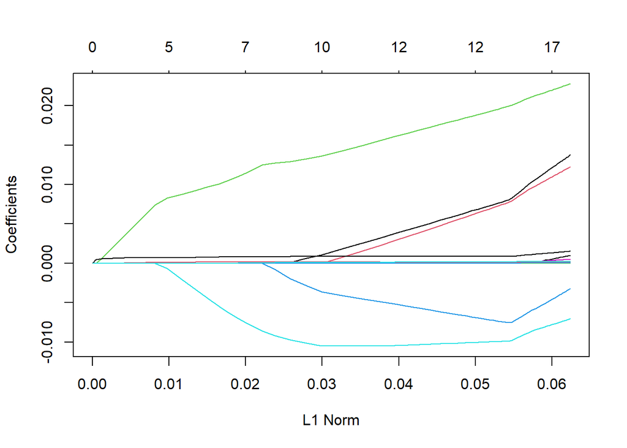

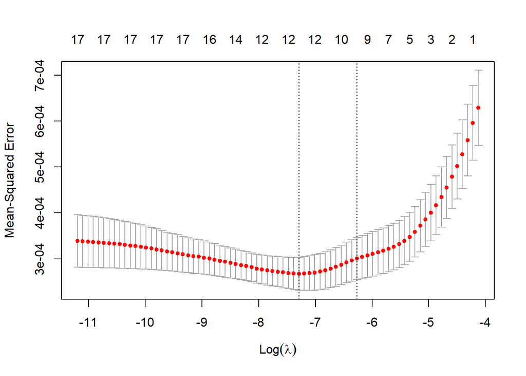

```
## 18 x 1 sparse Matrix of class "dgCMatrix"
##                                       1
## (Intercept)               -1.573514e-02
## WHO_regionAMRO             6.401158e-03
## WHO_regionEMRO             5.872233e-03
## WHO_regionEURO             1.845073e-02
## WHO_regionSEARO           -6.658355e-03
## WHO_regionWPRO            -1.010062e-02
## Population2020             .
## Pop_yearly_change          .
## Net.Change                 .
## population_density         1.199839e-05
## land_area                 -4.577160e-10
## Migrant_net_change         4.251619e-08
## Fert_rate                  .
## median_age                 8.770022e-04
## urban_population_percent   1.114662e-04
## GDP_per_capita             .
## health_expenditure_of_GDP  1.005825e-05
## median_stringency          1.746228e-04
```

## ridge

[figure not shown]

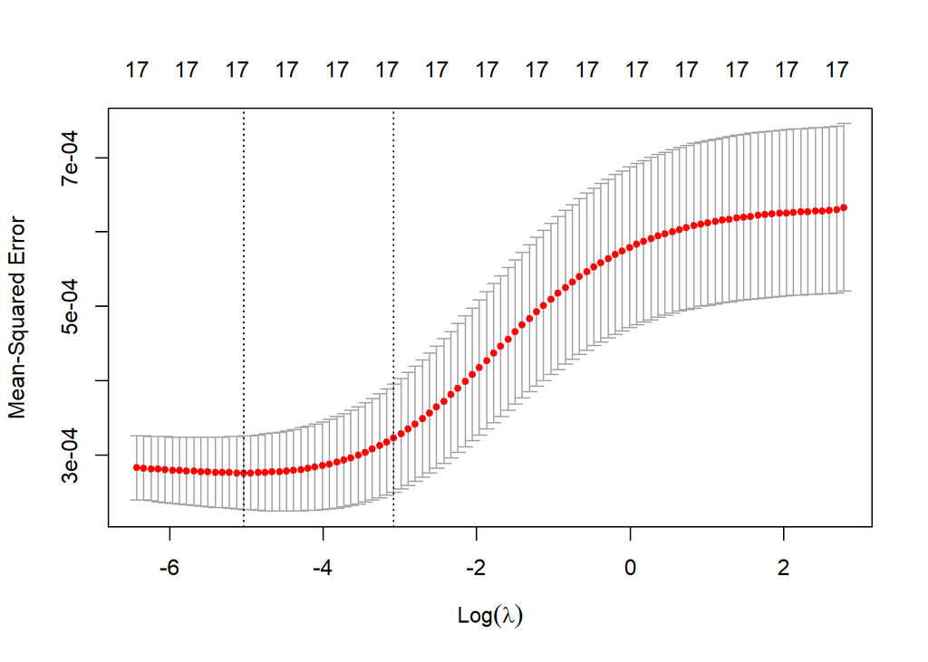

```
## 18 x 1 sparse Matrix of class "dgCMatrix"
##                                       1
## (Intercept)               -8.663506e-03
## WHO_regionAMRO             3.774383e-03
## WHO_regionEMRO             4.801076e-03
## WHO_regionEURO             1.462675e-02
## WHO_regionSEARO           -8.735492e-03
## WHO_regionWPRO            -1.101728e-02
## Population2020             1.558983e-12
## Pop_yearly_change         -1.018226e-03
## Net.Change                -5.441698e-10
## population_density         1.123526e-05
## land_area                 -5.609087e-10
## Migrant_net_change         3.984035e-08
## Fert_rate                 -1.401722e-04
## median_age                 5.951567e-04
## urban_population_percent   1.372542e-04
## GDP_per_capita             5.406923e-06
## health_expenditure_of_GDP  4.348694e-05
## median_stringency          1.705046e-04
```

## elastic net

The shining characteristic of Elastic net is that it combines the penalties of Ridge and Lasso regression. It is a combination of Ridge and Lasso in some way. In this case, we have two parameters to consider. 𝜆and α. α is the mix of ridge (α = 0) and lasso (α = 1).

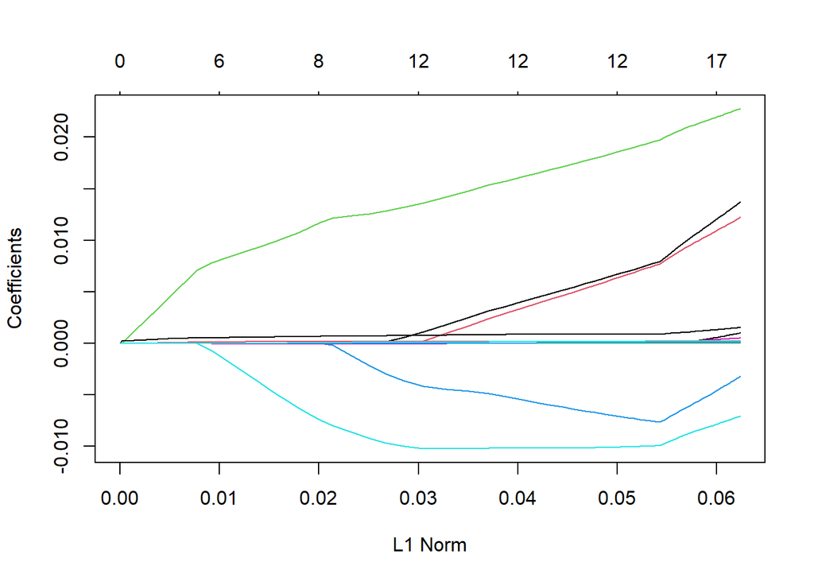

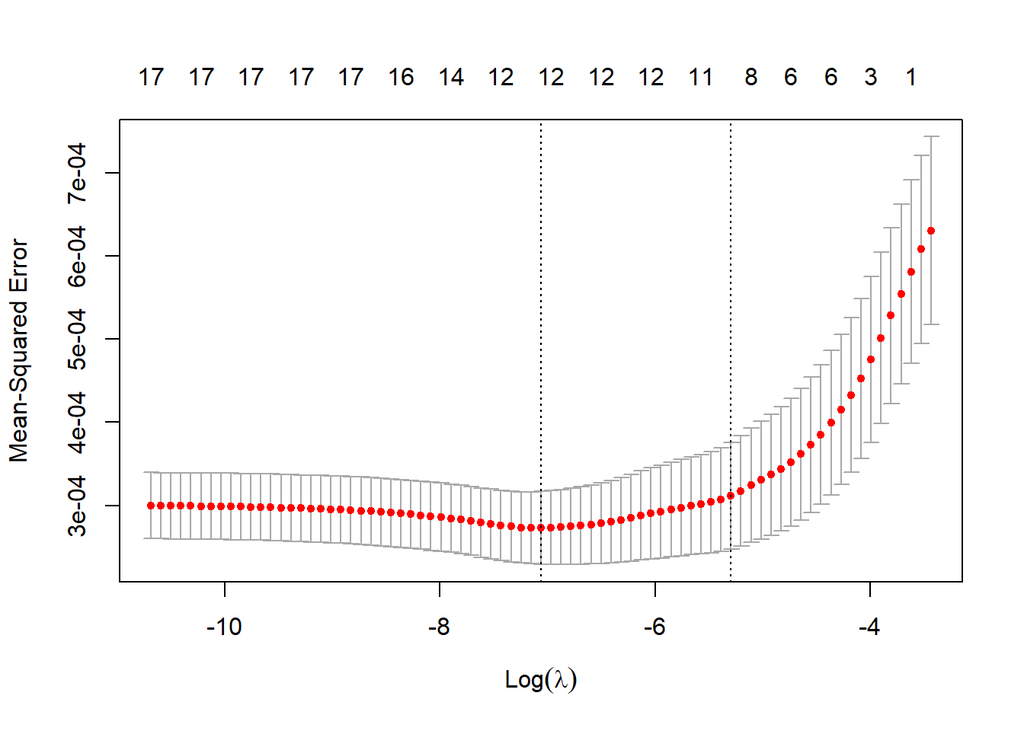

```
## [1] 0.0008577496
```

```
## [1] 0.592798
```

```
## [1] 0.0176508
```

```
## 18 x 1 sparse Matrix of class "dgCMatrix"
##                                       1
## (Intercept)               -2.056912e-02
## WHO_regionAMRO             7.777064e-03
## WHO_regionEMRO             7.865961e-03
## WHO_regionEURO             1.918689e-02
## WHO_regionSEARO           -7.459402e-03
## WHO_regionWPRO            -1.021170e-02
## Population2020             7.296130e-12
## Pop_yearly_change         -1.119468e-04
## Net.Change                -7.506649e-10
## population_density         1.354206e-05
## land_area                 -9.561549e-10
## Migrant_net_change         4.791238e-08
## Fert_rate                  6.381888e-05
## median_age                 8.927099e-04
## urban_population_percent   1.152630e-04
## GDP_per_capita             3.527060e-06
## health_expenditure_of_GDP  3.857512e-05
## median_stringency          2.024171e-04
```

In most cases, we need to apply all three regressions to the data and choose one after comparisons. No one can always outperform and has a higher power in description or prediction than others. Lasso deletes the useless or relatively meaningless variables for the model. The advantage of it is variable selection. Ridge regression has a higher power when there are many parameters affecting the response, while Lasso has a higher power when only a few parameters impacting the response. Elastic net is a combination of the two. It is hard to pre-determine which is better. We need to make comparisons in terms of data.

```
##              least square lambda     R square        R MSE
## linear lasso        0.0006828899 0.6282345893 0.0173332973
## linear ridge        0.0065185153 0.5427923876 0.0179675385
## elastic net         0.0008577496 0.5927980038 0.0176507992
```

From the table we can observe that the linear Lasso model has the highest R square value 0.628, the lowest R MSE, whcih is 0.0173332973

Here, R-squared means that approximately 62.8% variability of the response around the true values. It measures the percentage variance for the dependent variables.

MSE measures the difference between estimated values and the actual values(prediction errors). In our case, MSE is 0.0173332973 which is relatively low compared to ridge regression and elastic net regression. Thus we reach a conclusion that the linear lasso regression have the best prediction outcome out of all three. The model is successful to some degree since 62.8% of the variability in response variable can be explained by explanatory variable.

y = β<sub>0</sub> + β<sub>i</sub>Xj + ϵ, where i = j = 1···12

# Sensitivity Analysis

Since we use the linear lasso regression for prediction,the model should follow the linear regression assumption: 1: random samples are taken from all groups 2: all groups are independent 3: groups have constant variance 4: errors terms are normally distributed and are independent, no correlation with each other. 5: observations are independent and randomly selected.

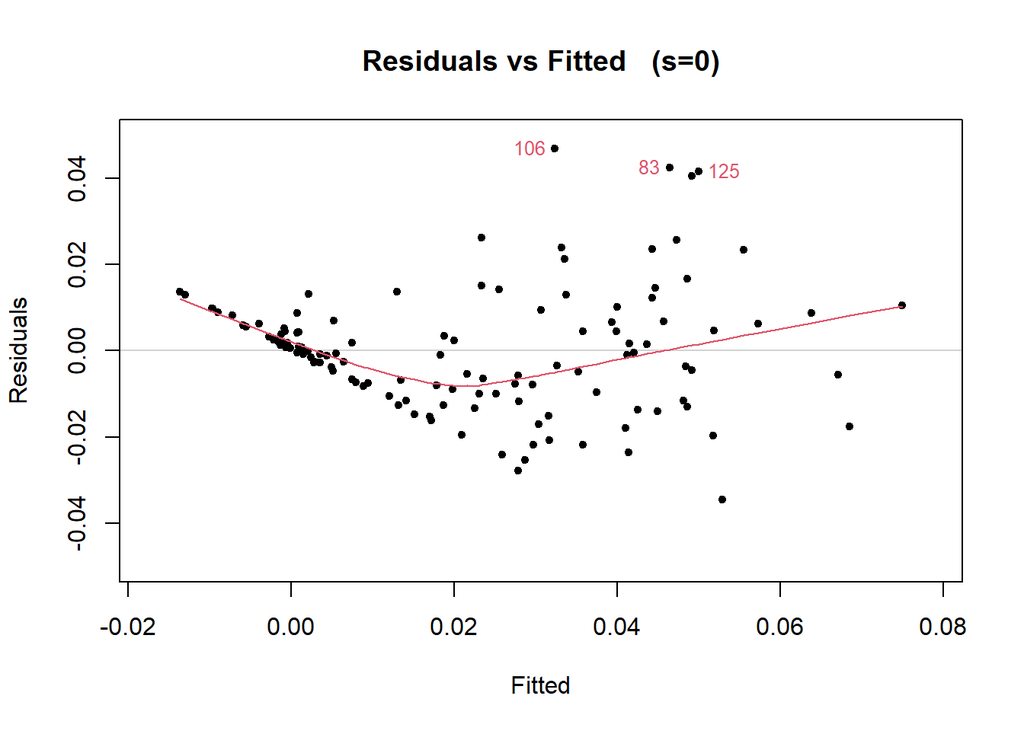

```r
# Lasso Model Diagnostic
library(plotmo)
plotres(lasso_mod, which = 3) # residual vs. fitted
```

The above Residuals vs. Fitted plot shows a negative linear pattern on its left half while no patterns detected on its right half. Furthermore, there are 3 extreme values present. Therefore, it might be somehow problematic to assume linear relationship between explanatory variables and response variables.

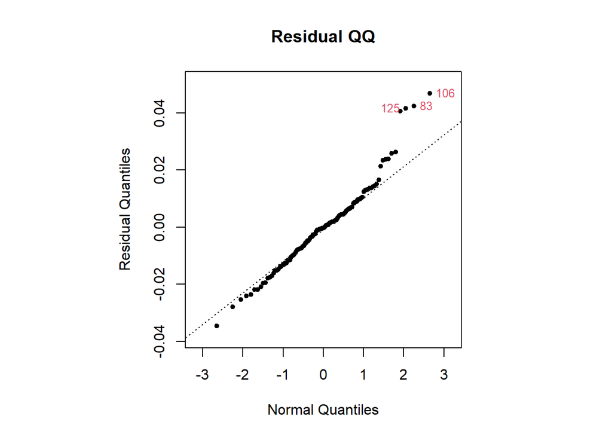

```r
plotres(lasso_mod, which = 4) # QQ plot
```

Since the right end is above the normal line, we have more extreme values than normal distribution for right end, which means that it has heavier tails. The confidence level that we constructed is actually smaller than the designed confidence level. Although the graph shows some level of heavier tails compare to Normal distribution, it is reasonable to assume the normality assumption holds because points locate relatively close to the normal line.

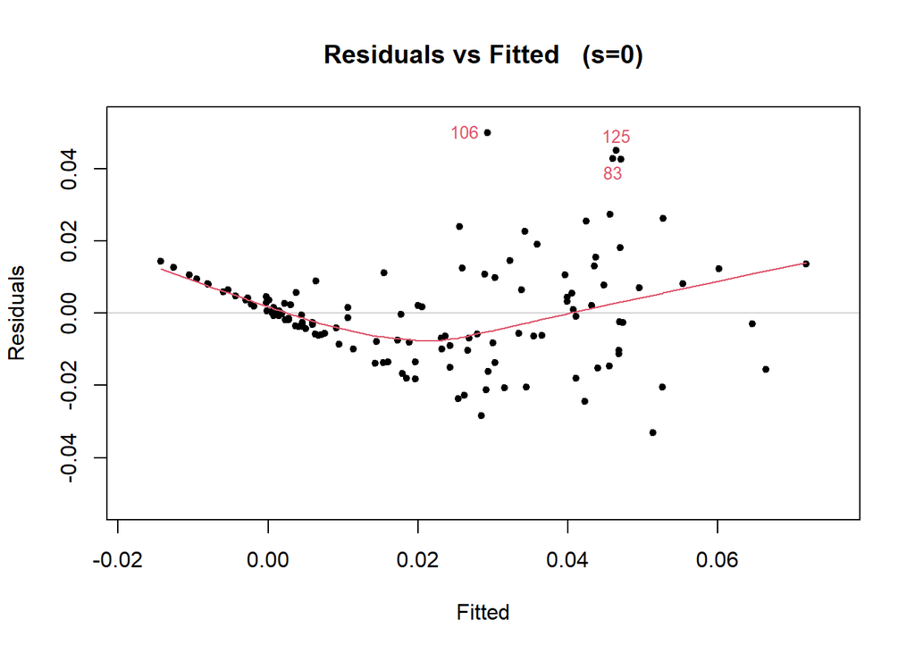

```r
# Ridge Model Diagnostic
plotres(ridge_mod, which = 3)
```

The above Residuals vs. Fitted plot shows a negative linear pattern on its left half while no patterns detected on its right half. Furthermore, there are 3 extreme values present. Therefore, it might be somehow problematic to assume linear relationship between explanatory variables and response variables.

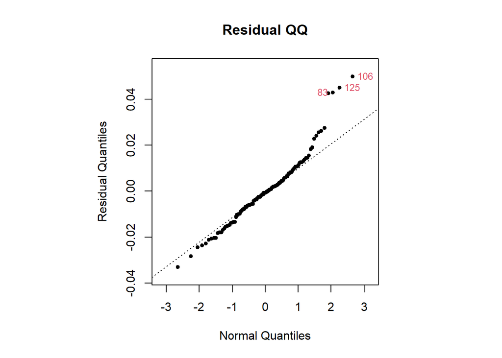

```r
plotres(ridge_mod, which = 4)
```

Even though the right tail is above the normal line, most of the residuals approximately follow normal line. Thus, it it reasonable to assume that normality assumption holds.

# Conclusion

In this report, we are trying to forecast the future outcomes on COVID-19 infection rate (i.e. positive cases per capita) based on current data by building a predictive model. Data we are using include the daily updated cumulative positive cases from WHO, 2020 population from Kaggle, GDP per capita from the United Nations Development Programme (UNDP), and health expenditure in % of GDP from World Bank.

The predictive outcomes could provide meaningful suggestions on policy regarding COVID-19 regulations so that we could lower the infection rate. For example, further enhancing the practice of social distancing especially in high population density counties and urban areas. To reduce the infection rate of immigrants, governments could provide COVID-19 regulation rules in immigrants’ native languages so that they could better understand and follow the suggestions. We could also suggest family give more attention to the elderly to protect them from catching the COVID-19.

Please note that the current analysis has a few limitations include:

- Because of the penalty algorithm of LASSO, some coefficients are shrunk to zero to reduce model over-fitting. However, it might result in under-fitting the model and therefore weaken the predictions. Furthermore, since LASSO is an automatic method, it does not allow analysts to think. In some circumstances, analysts would want to keep the variables in the model regardless of the measure of significance.
- Because we select the cumulative positive cases reported on one particular date, there are no time variables in our analysis. Therefore, it is hard to generalize the conclusion from this report to the future.
- One of the variables chosen might be time-sensitive because we only take the median of the stringency index (i.e. the strictness of COVID-19 regulation of government) of each country while the original data of stringency index is reported as daily measurement.
- The model accuracy could still improve on accuracy because there might be some other predictors or confounding variables that also play a role in predicting the outcomes.

# Acknowledgement

University Of California Davis Statistic 141A Class note by professor Shizhe Chen

# Reference

“Human Development Reports.” | Human Development Reports, hdr.undp.org/en/indicators/194906. Prabhu, Tanu N.

“Population by Country - 2020.” Kaggle, 3 Sept. 2020, www.kaggle.com/tanuprabhu/population-by-country-2020.

Ritchie, Research and data: Hannah. “Policy Responses to the Coronavirus Pandemic - Statistics and Research.” Our World in Data, ourworldindata.org/policy-responses-covid.

“WHO Coronavirus Disease (COVID-19) Dashboard.” World Health Organization, World Health Organization, covid19.who.int/. World Bank.

“Human Development Reports.” Gross Domestic Product (GDP), Total (2017 PPP $ Billions), 2021, hdr.undp.org/en/indicators/194506#.

# Session info

```r
knitr::opts_chunk$set(echo = TRUE)

library(tidyverse)
library(readr)
library(ggplot2)
WHO <-  read.csv("https://raw.githubusercontent.com/YixinXie10086/Project-141A/master/Main%20project/WHO-COVID-19-global-data%20(7).csv")

population <- read.csv('https://raw.githubusercontent.com/YixinXie10086/Project-141A/master/Main%20project/population_by_country_2020%20(1).csv') %>% filter_all(all_vars(!is.na(.)&(.!="N.A.")))

head(WHO)
head(population)
#Merge WHO data with Population data
names(population)[1] <- "Country"
names(WHO)[1] <- "date"
total_case=WHO %>% filter((date=='2021-03-01'))%>% select(Country,Cumulative_cases,WHO_region)

head(total_case)
head(population)



Stringency_index=read.csv('https://raw.githubusercontent.com/YixinXie10086/Project-141A/master/Main%20project/covid-stringency-index.csv')
Stringency_index

stringency=Stringency_index %>% filter((Date!="2020-01-01")|(Date!="2020-01-02"))%>%
  group_by(Code) %>%summarise(Country=unique(Entity),median_stringency=median(stringency_index)) %>%
  filter(!is.na(median_stringency)) %>% select(Country,median_stringency)

stringency


#matching country_name in 2 different datasets

match_country_name=function(set1,name1,name2){
  for (val in c(1:length(name1))){
    set1$Country=as.character(set1$Country)
    set1$Country[set1$Country==name1[val]]=as.character(name2[val])


  }

  return(set1)
}

name_list1=c("Czechia","Dominica","Timor","Venezuela (Bolivarian Republic of)")

name_list2=c("Czech Republic (Czechia)","Dominican Republic","Timor-Leste","Venezuela")
stringency=match_country_name(stringency,name_list1,name_list2)

population=inner_join(population,stringency,by='Country')
population
dim(population)



name_a=c('United States','Russia','Vietnam','Iran','United Kingdom',"Tanzania","South Korea","Venezuela","Côte d’Ivoire","North Korea","Syria","Bolivia","Czech Republic (Czechia)","Laos","Moldova","Brunei","Sao Tome & Principe",'Micronesia',"St. Vincent & Grenadines","Northern Mariana Islands","Saint Kitts & Nevis","Turks and Caicos","Wallis & Futuna","Saint Pierre & Miquelon",'Falkland Islands (Malvinas)')

name_b=c("United States of America","Russian Federation","Viet Nam","Iran (Islamic Republic of)","The United Kingdom","United Republic of Tanzania","Republic of Korea","Venezuela (Bolivarian Republic of)","Côte d’Ivoire","Democratic People's Republic of Korea","Syrian Arab Republic","Bolivia (Plurinational State of)","Czechia","Lao People's Democratic Republic","Republic of Moldova","Brunei Darussalam","Sao Tome and Principe","Micronesia (Federated States of)","Saint Vincent and the Grenadines","Northern Mariana Islands (Commonwealth of the)","Saint Kitts and Nevis","Turks and Caicos Islands","Wallis and Futuna","Saint Pierre and Miquelon","Falkland Islands (Malvinas)")

population=match_country_name(population,name_a,name_b)



data_attempt2=inner_join(total_case,population,by=c('Country'))
data_attempt2
dim(data_attempt2)
GDP_per_capita_19= read_csv('https://raw.githubusercontent.com/YixinXie10086/Project-141A/master/Main%20project/GDP%20per%20capita%20(2017%20PPP%20%24).csv',skip=5)%>% select(Country,`2019`)

colnames(GDP_per_capita_19)[2]="GDP per Capita $PPP 2019"

GDP_per_capita_19$Country=as.character(GDP_per_capita_19$Country)


list1=c("Tanzania (United Republic of)",'United Kingdom','United States',"Korea (Republic of)","Moldova (Republic of)")
list2=c("United Republic of Tanzania","The United Kingdom","United States of America","Republic of Korea","Republic of Moldova")

GDP_per_captia_19=match_country_name(GDP_per_capita_19,list1,list2)
data3=inner_join(data_attempt2,GDP_per_captia_19)%>% filter(`GDP per Capita $PPP 2019`!="..")
data3

dim(data3)
# merge data with health expenditure
health_expenditure <- read.csv("https://raw.githubusercontent.com/YixinXie10086/Project-141A/master/Main%20project/Current%20health%20expenditure%20(%25%20of%20GDP).csv",skip = 6, header = T) %>%
  filter(X2017!="..") %>% select(Country,X2017)

colnames(health_expenditure)[2]="health expenditure in percent of GDP"

for (i in c(1:length(health_expenditure$Country))){
  health_expenditure$Country[i]<- iconv(enc2utf8(health_expenditure$Country[i]),sub="byte")
  health_expenditure$Country[i]=substr(health_expenditure$Country[i],2,nchar(health_expenditure$Country[i]))

}





list1=c("Congo (Democratic Republic of the)","Côte d'Ivoire","Eswatini (Kingdom of)","Korea (Republic of)","Lao People's Democratic Republic","Moldova (Republic of)","United Kingdom","United States")
list2=c("Democratic Republic of the Congo","Côte d’Ivoire","Eswatini","Republic of Korea","Lao People's Democratic Republic","Republic of Moldova","The United Kingdom","United States of America")


health_expenditure2=match_country_name(health_expenditure,list1,list2)
health_expenditure2$Country=as.character(health_expenditure2$Country)
#health_expenditure2$Country=as.character(health_expenditure$Country)

data4=inner_join(data3,health_expenditure2,by="Country")
health_expenditure2$Country

data4
dim(data4)



d_rate_table<- data4 %>% select(-Country) %>% mutate_if(is.character,as.factor)

d_rate_table$`Yearly.Change`=as.character(d_rate_table$`Yearly.Change`)
d_rate_table$`Urban.Pop..`=as.character(d_rate_table$`Urban.Pop..`)
d_rate_table$`World.Share`=as.character(d_rate_table$`World.Share`)

#remove the % sign and change features into numberic
for (i in c(1:length(d_rate_table$`Yearly.Change`))){
  d_rate_table$`Yearly.Change`[i]<- iconv(enc2utf8(d_rate_table$`Yearly.Change`[i]),sub="byte")
  d_rate_table$`Yearly.Change`[i]=substr(d_rate_table$`Yearly.Change`[i],1,nchar(d_rate_table$`Yearly.Change`[i])-1)
}


for (i in c(1:length(d_rate_table$`Urban.Pop..`))){
  d_rate_table$`Urban.Pop..`[i]<- iconv(enc2utf8(d_rate_table$`Urban.Pop..`[i]),sub="byte")
  d_rate_table$`Urban.Pop..`[i]=substr(d_rate_table$`Urban.Pop..`[i],1,nchar(d_rate_table$`Urban.Pop..`[i])-1)
}

for (i in c(1:length(d_rate_table$`World.Share`))){
  d_rate_table$`World.Share`[i]<- iconv(enc2utf8(d_rate_table$`World.Share`[i]),sub="byte")
  d_rate_table$`World.Share`[i]=substr(d_rate_table$`World.Share`[i],1,nchar(d_rate_table$`World.Share`[i])-1)
}



d_rate_table

d_rate_table2=d_rate_table %>%
  summarize(infected_rate=(Cumulative_cases/`Population..2020.`),WHO_region=WHO_region,Population2020=`Population..2020.`,Pop_yearly_change=as.numeric(`Yearly.Change`),Net.Change=Net.Change,population_density=d_rate_table[,6],land_area=d_rate_table[,7],Migrant_net_change=d_rate_table[,8],Fert_rate=as.numeric(`Fert..Rate`), median_age=as.numeric(`Med..Age`),urban_population_percent=as.numeric(`Urban.Pop..`),GDP_per_capita=as.numeric(`GDP per Capita $PPP 2019`),health_expenditure_of_GDP=as.numeric(`health expenditure in percent of GDP`),median_stringency=median_stringency
)






d_rate_table2
dim(d_rate_table2)
#d_rate_table is the dataframe to use
head(d_rate_table2)
summary(d_rate_table2)
library(dplyr)
library(tidyverse)
world <- map_data("world")
case.counts <- data4 %>%
  select(Country, Cumulative_cases) %>%
  rename(region = Country, case = Cumulative_cases)
life.exp.map <- left_join(case.counts, world, by = "region")
ggplot(life.exp.map, aes(long, lat, group = group))+
  geom_polygon(aes(fill = case), color = "white")+
  scale_fill_viridis_c(option = "C")
ggplot(d_rate_table2, aes(x=GDP_per_capita, y=infected_rate, shape=WHO_region, color=WHO_region)) +
  geom_point()
ggplot(d_rate_table2, aes(x=health_expenditure_of_GDP, y=infected_rate, shape=WHO_region, color=WHO_region)) +
  geom_point()

#Lasso approach
set.seed(1)
library(caret)
library(glmnet)
set.seed(1)
d_rate_table=as.tibble(d_rate_table2)
#partition data into 50 percent.
index_80percent= createDataPartition(d_rate_table2$infected_rate,p=0.8,list=FALSE,times=1)

#test and training.
train=d_rate_table2[index_80percent,]
test=d_rate_table2[-index_80percent,]


#train=d_rate_table %>% sample_frac(0.8)
#test=d_rate_table %>% setdiff(train)
x_train=model.matrix(infected_rate~.,train)[,-1]
x_test=model.matrix(infected_rate~.,test)[,-1]
y_train=train %>% select(infected_rate) %>% unlist() %>% as.numeric()
y_test=test %>% select(infected_rate) %>% unlist() %>% as.numeric()


lasso_mod=glmnet(x_train,y_train,alpha=1 )
plot(lasso_mod)
cv.train=cv.glmnet(x_train,y_train,alpha=1,type.measure = "mse", standardize = TRUE, nfolds = 10)
plot(cv.train)
best_lam=cv.train$lambda.min


lasso_pred = predict(lasso_mod, s = best_lam, newx = x_test)


r2 <- cv.train$glmnet.fit$dev.ratio[which(cv.train$glmnet.fit$lambda == cv.train$lambda.1se)]

Rmse_lasso=sqrt(cv.train$cvm[cv.train$lambda == cv.train$lambda.1se])

lasso_coef = predict(lasso_mod, type = "coefficients", s = best_lam)


lasso_coef

#ridge regression
set.seed(1)
ridge_mod=glmnet(x_train,y_train,alpha=0)
plot(lasso_mod)
cv.train_lasso=cv.glmnet(x_train,y_train,alpha=0,type.measure = "mse", standardize = TRUE, nfolds = 10)




plot(cv.train_lasso)
best_lam_ridge=cv.train_lasso$lambda.min



ridge_pred = predict(ridge_mod, s = best_lam, newx = x_test)


r2_ridge <- cv.train_lasso$glmnet.fit$dev.ratio[which(cv.train_lasso$glmnet.fit$lambda == cv.train_lasso$lambda.1se)]

Rmse_ridge=sqrt(cv.train_lasso$cvm[cv.train_lasso$lambda == cv.train_lasso$lambda.1se])


ridge_coef = predict(ridge_mod, type = "coefficients", s = best_lam_ridge)

ridge_coef
set.seed(1)
ela_mod=glmnet(x_train,y_train,alpha=0.5)
plot(ela_mod)
cv.train=cv.glmnet(x_train,y_train,alpha=0.5,type.measure = "mse", standardize = TRUE, nfolds = 10)




plot(cv.train)
best_lam_elastic=cv.train$lambda.min
best_lam_elastic


elastic_pred = predict(ridge_mod, s = best_lam_elastic, newx = x_test)


r2_ela <- cv.train$glmnet.fit$dev.ratio[which(cv.train$glmnet.fit$lambda == cv.train$lambda.1se)]
r2_ela

Rmse_ela=sqrt(cv.train$cvm[cv.train$lambda == cv.train$lambda.1se])
Rmse_ela

ridge_coef = predict(ridge_mod, type = "coefficients", s = best_lam_elastic)

ridge_coef


table_report= matrix(c(best_lam,r2,Rmse_lasso,best_lam_ridge,r2_ridge,Rmse_ridge,best_lam_elastic,r2_ela,Rmse_ela),ncol=3,byrow=TRUE)
colnames(table_report) <- c("least square lambda","R square","R MSE")
rownames(table_report) <- c("linear lasso","linear ridge","elastic net")
table_report <- as.table(table_report)
table_report


# Lasso Model Diagnostic
library(plotmo)
plotres(lasso_mod, which = 3) # residual vs. fitted
plotres(lasso_mod, which = 4) # QQ plot
# Ridge Model Diagnostic
plotres(ridge_mod, which = 3)
plotres(ridge_mod, which = 4)
```